# Days of Code Austin 2018

Carlos Santillan

February 10, 2018

# Analysis of Opiod drug overdoses data from the CDC

Carlos Santillan

csantill@gmail.com

https://www.linkedin.com/in/carlos-santillan/

## Load the data

Load CDC data Dataset: Underlying Cause of Death, 1999-2016

### Load Monthly Data

Group By: State, Year, Month, ICD Chapter

ICD-10 Codes:

- X40 (Accidental poisoning by and exposure to nonopioid analgesics, antipyretics and antirheumatics)
- X41 (Accidental poisoning by and exposure to antiepileptic, sedative-hypnotic, antiparkinsonism and psychotropic drugs, not elsewhere classified)
- X42 (Accidental poisoning by and exposure to narcotics and psychodysleptics [hallucinogens], not elsewhere classified)
- X43 (Accidental poisoning by and exposure to other drugs acting on the autonomic nervous system)
- X44 (Accidental poisoning by and exposure to other and unspecified drugs, medicaments and biological substances)
- X60 (Intentional self-poisoning by and exposure to nonopioid analgesics, antipyretics and antirheumatics)
- X61 (Intentional self-poisoning by and exposure to antiepileptic, sedative-hypnotic, antiparkinsonism and psychotropic drugs, not elsewhere classified)
- X62 (Intentional self-poisoning by and exposure to narcotics and psychodysleptics [hallucinogens], not elsewhere classified)
- X63 (Intentional self-poisoning by and exposure to other drugs acting on the autonomic nervous system)
- X64 (Intentional self-poisoning by and exposure to other and unspecified drugs, medicaments and biological substances)
- Y10 (Poisoning by and exposure to nonopioid analgesics, antipyretics and antirheumatics, undetermined intent)
- Y11 (Poisoning by and exposure to antiepileptic, sedative-hypnotic, antiparkinsonism and psychotropic drugs, not elsewhere classified, undetermined intent),
- Y12 (Poisoning by and exposure to narcotics and psychodysleptics [hallucinogens], not elsewhere classified, undetermined intent)
- Y13 (Poisoning by and exposure to other drugs acting on the autonomic nervous system, undetermined intent)
- Y14 (Poisoning by and exposure to other and unspecified drugs, medicaments and biological substances, undetermined intent)

Source:

Centers for Disease Control and Prevention, National Center for Health Statistics. Underlying Cause of Death 1999-2016 on CDC WONDER Online Database, released December, 2017. Data are from the Multiple Cause of Death Files, 1999-2016, as compiled from data provided by the 57 vital statistics jurisdictions through the Vital Statistics Cooperative Program. Accessed at http://wonder.cdc.gov/ucd-icd10.html on Feb 10, 2018 4:36:12 PM

- Note: Year, Month data for the state of South Dakota and North Dakota was unavailable due to CDC Suppression, data was inputed by floor (AnnualDeaths/ 12 ) for each year

Use of this data allowed under https://wonder.cdc.gov/DataUse.html#

CDC Data was generated from the following Query https://wonder.cdc.gov/controller/saved/D76/D29F799

### Load Annual Data

Group By: State, Year, ICD Chapter

ICD-10 Codes:

- X40 (Accidental poisoning by and exposure to nonopioid analgesics, antipyretics and antirheumatics)
- X41 (Accidental poisoning by and exposure to antiepileptic, sedative-hypnotic, antiparkinsonism and psychotropic drugs, not elsewhere classified)
- X42 (Accidental poisoning by and exposure to narcotics and psychodysleptics [hallucinogens], not elsewhere classified)
- X43 (Accidental poisoning by and exposure to other drugs acting on the autonomic nervous system)
- X44 (Accidental poisoning by and exposure to other and unspecified drugs, medicaments and biological substances)
- X60 (Intentional self-poisoning by and exposure to nonopioid analgesics, antipyretics and antirheumatics)
- X61 (Intentional self-poisoning by and exposure to antiepileptic, sedative-hypnotic, antiparkinsonism and psychotropic drugs, not elsewhere classified)
- X62 (Intentional self-poisoning by and exposure to narcotics and psychodysleptics [hallucinogens], not elsewhere classified)
- X63 (Intentional self-poisoning by and exposure to other drugs acting on the autonomic nervous system)
- X64 (Intentional self-poisoning by and exposure to other and unspecified drugs, medicaments and biological substances)
- Y10 (Poisoning by and exposure to nonopioid analgesics, antipyretics and antirheumatics, undetermined intent)
- Y11 (Poisoning by and exposure to antiepileptic, sedative-hypnotic, antiparkinsonism and psychotropic drugs, not elsewhere classified, undetermined intent),
- Y12 (Poisoning by and exposure to narcotics and psychodysleptics [hallucinogens], not elsewhere classified, undetermined intent)
- Y13 (Poisoning by and exposure to other drugs acting on the autonomic nervous system, undetermined intent)
- Y14 (Poisoning by and exposure to other and unspecified drugs, medicaments and biological substances, undetermined intent)

Source:

Centers for Disease Control and Prevention, National Center for Health Statistics. Underlying Cause of Death" “1999-2016 on CDC WONDER Online Database, released December, 2017. Data are from the Multiple Cause of Death Files, 1999-2016, as” “compiled from data provided by the 57 vital statistics jurisdictions through the Vital Statistics Cooperative Program. Accessed” “at http://wonder.cdc.gov/ucd-icd10.html on Feb 13, 2018 11:26:09 AM”

Use of this data allowed under https://wonder.cdc.gov/DataUse.html#

CDC Data was generated from the following Query https://wonder.cdc.gov/controller/saved/D76/D29F799 https://wonder.cdc.gov/controller/saved/D76/D30F044

## Load Geo data

Latitudeo and Longitude Coordinates for each state were downloaded from https://inkplant.com/code/state-latitudes-longitudes

### Exploration

```
## tibble [10,107 x 7] (S3: tbl_df/tbl/data.frame)
##  $ State     : chr [1:10107] "Alabama" "Alabama" "Alabama" "Alabama" ...
##  $ YearMonth : chr [1:10107] "1999-01" "1999-02" "1999-03" "1999-04" ...
##  $ Year      : chr [1:10107] "1999" "1999" "1999" "1999" ...
##  $ Month.Code: chr [1:10107] "01" "02" "03" "04" ...
##  $ Deaths    : int [1:10107] 17 13 10 14 13 20 11 20 21 17 ...
##  $ Lat       : num [1:10107] 32.8 32.8 32.8 32.8 32.8 ...
##  $ Long      : num [1:10107] -86.8 -86.8 -86.8 -86.8 -86.8 ...
```

```
## # A tibble: 6 x 7
##   State   YearMonth Year  Month.Code Deaths   Lat  Long
##   <chr>   <chr>     <chr> <chr>       <int> <dbl> <dbl>
## 1 Alabama 1999-01   1999  01             17  32.8 -86.8
## 2 Alabama 1999-02   1999  02             13  32.8 -86.8
## 3 Alabama 1999-03   1999  03             10  32.8 -86.8
## 4 Alabama 1999-04   1999  04             14  32.8 -86.8
## 5 Alabama 1999-05   1999  05             13  32.8 -86.8
## 6 Alabama 1999-06   1999  06             20  32.8 -86.8
```

```
##     State            YearMonth             Year            Month.Code
##  Length:10107       Length:10107       Length:10107       Length:10107
##  Class :character   Class :character   Class :character   Class :character
##  Mode  :character   Mode  :character   Mode  :character   Mode  :character
##
##
##
##      Deaths            Lat             Long
##  Min.   : 10.00   Min.   :21.09   Min.   :-157.50
##  1st Qu.: 26.00   1st Qu.:35.57   1st Qu.: -98.27
##  Median : 51.00   Median :39.06   Median : -86.79
##  Mean   : 74.97   Mean   :38.59   Mean   : -92.03
##  3rd Qu.: 90.00   3rd Qu.:42.01   3rd Qu.: -79.81
##  Max.   :546.00   Max.   :61.37   Max.   : -69.38
```

```
## [1] "Deaths reported in 2016 "
```

```
## [1] 63186
```

```
## [1] "Deaths reported in the state of Texas 2016 "
```

| x |
| --- |
| 2822 |

```
## # A tibble: 6 x 3
## # Groups:   State, YearMonth [6]
##   State YearMonth Deaths
##   <chr> <chr>      <int>
## 1 Texas 1999-01       72
## 2 Texas 1999-02       97
## 3 Texas 1999-03      101
## 4 Texas 1999-04       99
## 5 Texas 1999-05       86
## 6 Texas 1999-06       77
```

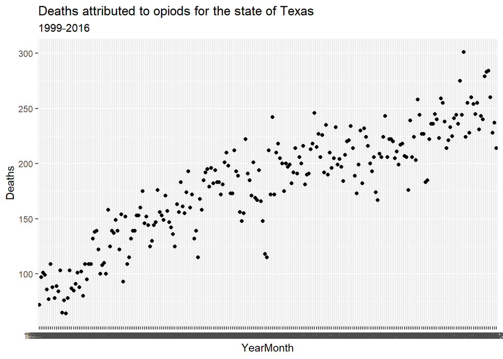

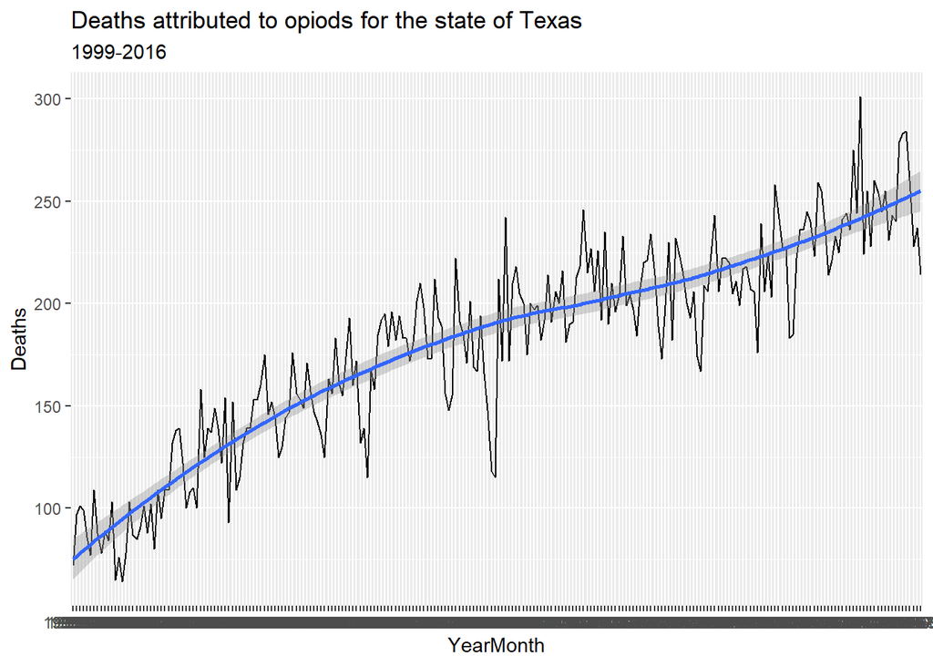

Deaths attributed to opiods in the United State

| Year | Deaths | PercentChange |
| --- | --- | --- |
| 2018 | 67,251 | -4.0573507 |
| 2017 | 70,095 | 10.3475961 |
| 2016 | 63,522 | 21.4314389 |
| 2015 | 52,311 | 11.3616043 |
| 2014 | 46,974 | 7.0120284 |
| 2013 | 43,896 | 5.9726715 |
| 2012 | 41,422 | 0.3926321 |
| 2011 | 41,260 | 7.8213604 |
| 2010 | 38,267 | 3.6091406 |
| 2009 | 36,934 | 1.5172338 |
| 2008 | 36,382 | 1.2044841 |
| 2007 | 35,949 | 4.6550218 |
| 2006 | 34,350 | 15.4389031 |
| 2005 | 29,756 | 8.7891196 |
| 2004 | 27,352 | 6.2750126 |
| 2003 | 25,737 | 9.6357827 |
| 2002 | 23,475 | 21.3052914 |
| 2001 | 19,352 | 11.3207547 |
| 2000 | 17,384 | 3.4207865 |
| 1999 | 16,809 | NA |

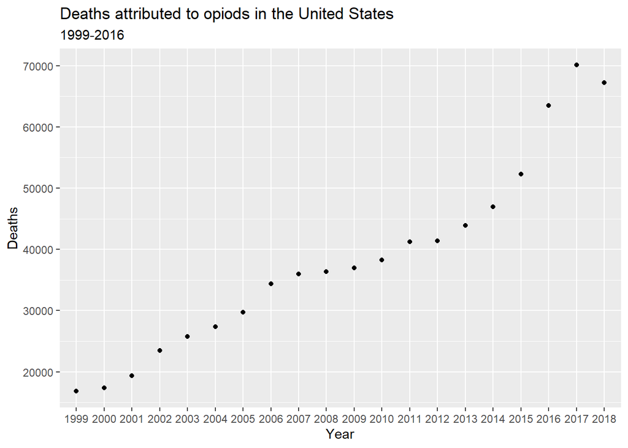

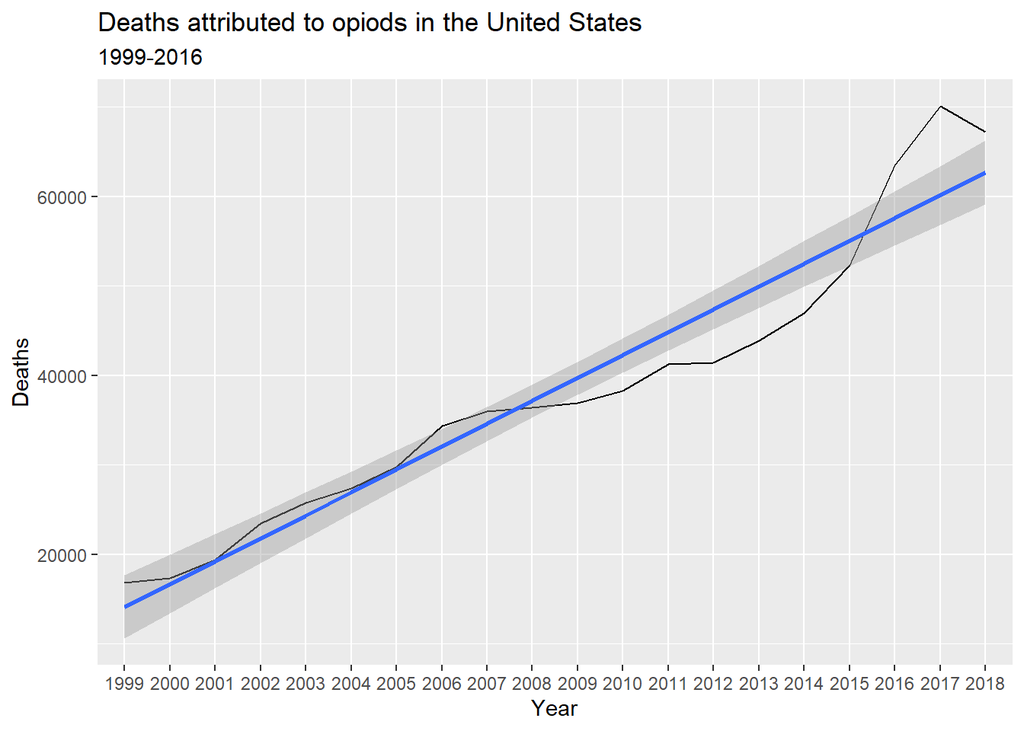

States with Highest number of deaths for 2016

| State | Deaths |
| --- | --- |
| Florida | 4,724 |
| California | 4,649 |
| Pennsylvania | 4,609 |
| Ohio | 4,318 |
| New York | 3,636 |
| Texas | 2,822 |

States with Lowest number of deaths for 2016

| State | Deaths |
| --- | --- |
| Vermont | 125 |
| Nebraska | 120 |
| Montana | 118 |
| Wyoming | 98 |
| North Dakota | 77 |
| South Dakota | 68 |

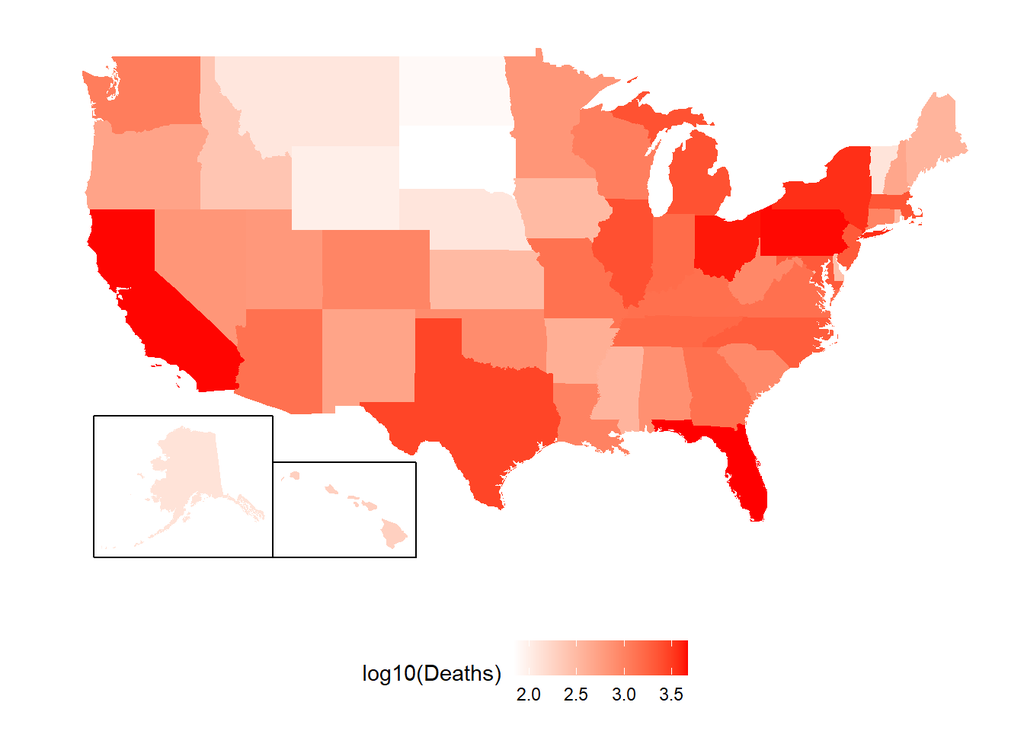